# R Zone 6: Chapter 21 and 22

Brandon Hufstetler, Garrett Alarcon, Jinan Andrews, Anson Cheng, Nick Forrest, and Nestor Herandez

19 August 2019

# Chapter 21

### OPEN REQUIRED PACKAGE, READ IN THE DATA

#### Commentary: Note that birch is no longer supported on CRAN and must be installed through an archived version. The approval and interest were removed from the classification training data because the interest is perfectly correlated with the requested amount. Also, the original R-Zone code says to use 5000 records but is scripted to only load in 1000 values. The correction was made below.

```r
  #install.packages("birch")
  setwd("~/IMGT680")
  library(birch)
  loan.test <- read.csv(file="Loans_Test.csv", header = TRUE)
  loan.train <- read.csv(file="Loans_Training.csv", header = TRUE)

  # Use 5,000 records for a small example
  train <- as.matrix(loan.train[1:5000,-c(1,5)])
```

### BIRCH CLUSTERING

#### Commentary: The following snippet first creates the CF tree (radius 1000) using the birch() command, then uses kmeans to classify the birch clusters, with 2 centroids.

```r
  b1 <- birch(x = train, radius=1000) # Create the Birch tree

  # Cluster the sub-clusters using kmeans
  kb1 <- kmeans.birch(birchObject = b1, centers = 2, nstart = 1)
```

### PLOT THE RESULTS

#### Commentary: Since only one value of k is selected (2), we cannot make a comparison to different models and BIRCH is unable to suggest a k. The CF tree clearly splits the data into two distinct categories when viewing the loan amount vs FICO score.

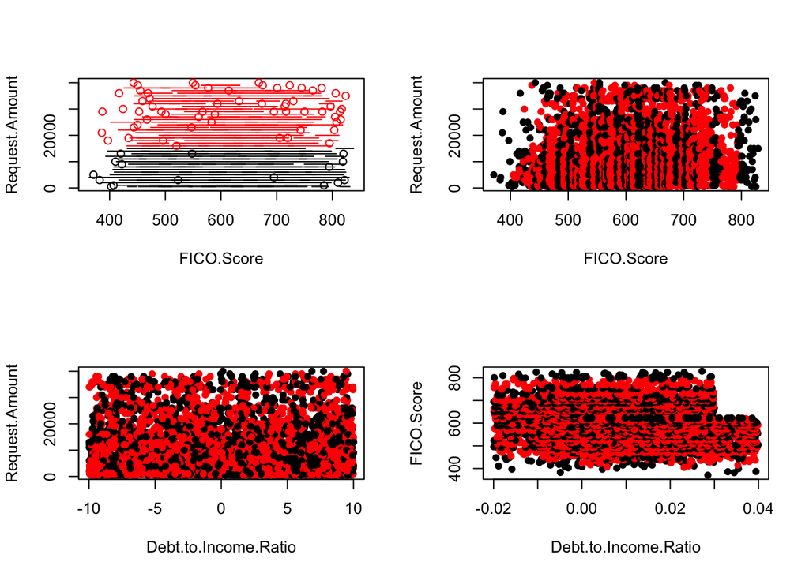

```r
  par(mfrow=c(2,2))
  plot(b1[,c(2,3)], col = kb1$clust$sub)
  plot(train[,c(2,3)], col = kb1$clust$sub, pch = 16)
  plot(jitter(train[,c(1,3)], .1), col = kb1$clust$sub, pch = 16)
  plot(jitter(train[,c(1,2)], .1), col = kb1$clust$sub, pch = 16)
```

# Chapter 22

### READ IN AND PREPARE THE DATA

#### Commentary: Iris data used here. Min-max normalization applied to normalize all variables (from chapter 2)

```r
  i.data <- iris # Iris is a built-in dataset
  # Min-max normalization
  i.data$SL <- (i.data$Sepal.Length - min(i.data$Sepal.Length))/
    (max(i.data$Sepal.Length) - min(i.data$Sepal.Length))
  i.data$SW <- (i.data$Sepal.Width - min(i.data$Sepal.Width))/
    (max(i.data$Sepal.Width) - min(i.data$Sepal.Width))
  i.data$PL <- (i.data$Petal.Length - min(i.data$Petal.Length))/
    (max(i.data$Petal.Length) - min(i.data$Petal.Length))
  i.data$PW <- (i.data$Petal.Width - min(i.data$Petal.Width))/
    (max(i.data$Petal.Width) - min(i.data$Petal.Width))
```

### SILHOUETTE VALUES

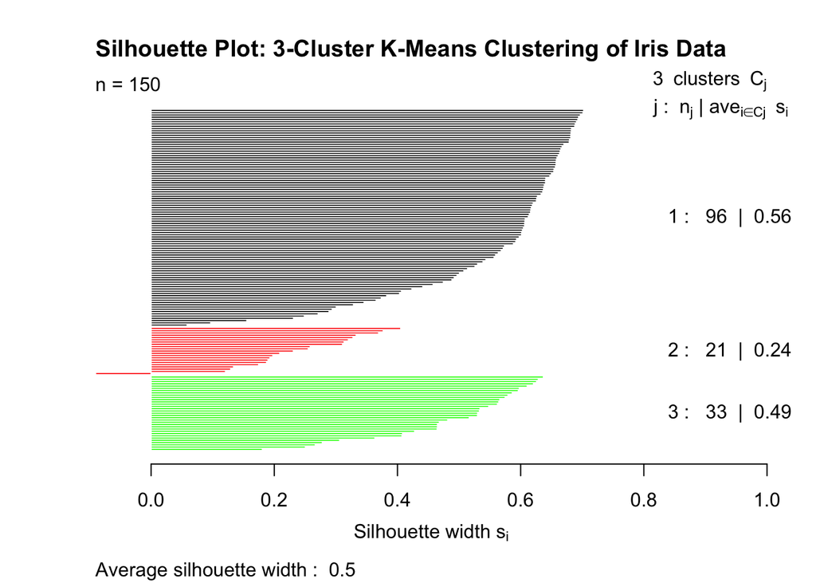

```r
  # Requires package 'cluster'
  #install.packages("cluster")
  library(cluster)

  # k-means (k=3)
  km1 <- kmeans(i.data[,6:9], 3)
  dist1 <- dist(i.data[,6:9], method = "euclidean")
  sil1 <- silhouette(km1$cluster, dist1)
  plot(sil1, col = c("black", "red", "green"),
       main = "Silhouette Plot: 3-Cluster K-Means Clustering of Iris Data")
```

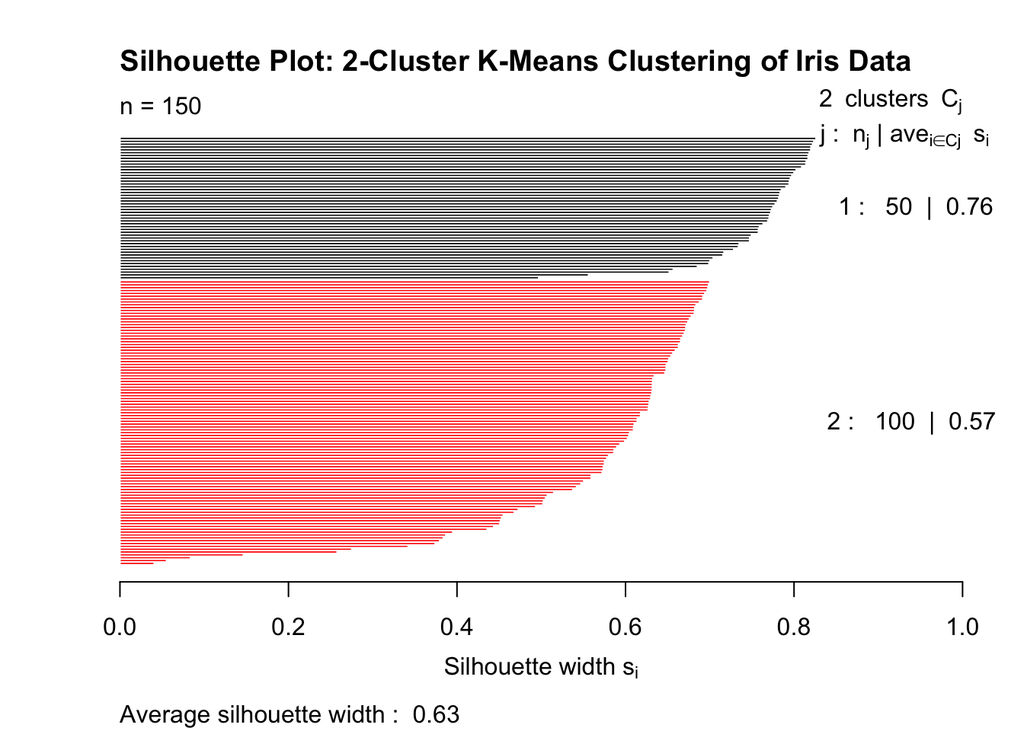

```r
  # k-means (k=2)
  km2 <- kmeans(i.data[,6:9], 2)
  dist2 <- dist(i.data[,6:9], method = "euclidean")
  sil2 <- silhouette(km2$cluster, dist2)
  plot(sil2, col = c("black", "red"),
       main = "Silhouette Plot: 2-Cluster K-Means Clustering of Iris Data")
```